# AD_CSF_Meta-Analysis

2022-04-20

# 0. Preparations & Imports

### Libraries, functions, imports

Import Libraries

```r
library(readxl)
library(tidyverse)
library(ggpubr)
library(rstatix)
library(msigdbr)
library(clusterProfiler)
library(ggrepel)
library(ggthemes)
library(gridExtra)
library(eulerr)
library(pROC)
library(ggbeeswarm)
library(ComplexHeatmap)
library(circlize)
library(extrafont)
library(wesanderson)
library(DT)
library(enrichR)
loadfonts(device = "win")
```

### Functions

Create functions to import Fragpipe TMT and LFQ data. Create a function to detect and remove outliers (and visualize).

```r
#Create Functions to clean the datasets. four in total: TMT-protein, TMT-peptide, LFQ-protein, LFQ-peptide.
#Goal is to get to a long(tidy)format for each. For LFQ ones we also log transform.
cleanTMT_protein <- function(dataset){
  colnames_TMT_Protein <- colnames(dataset)[6:ncol(dataset)]
  dataset <- dataset %>% gather(colnames_TMT_Protein, key = "Sample", value = "Intensity") %>%
  mutate(ID = paste0(Index, "_", Gene)) %>%
  select(ID, Sample, Intensity)
  return(dataset)
}
cleanLFQ_protein <- function(dataset){
  names(dataset)[names(dataset) == 'Protein ID'] <- 'ProteinID'
  dataset <- dataset %>%
    mutate(ID = paste0(ProteinID, "_", Gene)) %>%
    dplyr::select(ID, contains("MaxLFQ Total Intensity")) #%>% select(-contains("MaxLFQ"))
  dataset <- dataset %>%
    gather(colnames(dataset)[2:ncol(dataset)], key = "Sample", value = "Intensity")
}

OutlierRemover <- function(dataset, name){
  #Determine correlations between sample and theoretical
  SampleCorrelations <- dataset%>%
    mutate(SampleDX = paste0(Sample,"_", DX)) %>%
    group_by(ID) %>%
    mutate(medianProtein = median(Intensity, na.rm = T)) %>%
    ungroup() %>%
    group_by(Sample) %>%
    mutate(SampleCor = cor(Intensity, medianProtein, method = "pearson", use="complete.obs")) %>%
    ungroup() %>%
    distinct(SampleDX, .keep_all = T)

  SampleCorrelations <- SampleCorrelations %>%
    mutate(Outlier = SampleCor < (1 - 4*sd(unique(SampleCorrelations$SampleCor))))

    #Make the DF that we will return (i.e. without outliers)
  returnDataset <- dataset %>%
    dplyr::filter(Sample %in% dplyr::filter(SampleCorrelations, Outlier == F)$Sample) %>%
    select(ID, Sample, DX, Intensity)

  #Purely for visualization: Also attached PCA Plots of the removed samples

  #PCA PLOT: 70% cut off
  ProteinsToKeep <- dataset %>%
    group_by(ID) %>%
    summarise(PercentMissing = sum(!is.na(Intensity))/ length(unique(dataset$Sample))) %>%
    mutate(remove = PercentMissing > 0.7) %>%
    dplyr::filter(remove == T)

  #Half minimum value (per protein) imputation
  PCA_DF <- dataset %>%
    dplyr::filter(ID %in% ProteinsToKeep$ID) %>%
    group_by(ID) %>%
    mutate(IntensImputed = replace_na(Intensity, mean(Intensity, na.rm = T)/2)) %>%
    mutate(SampleDX = paste0(Sample,"_", DX)) %>%
    select(ID, SampleDX, IntensImputed) %>%
    spread(key = "ID", value = "IntensImputed") %>%
    column_to_rownames("SampleDX")

  #scale and PCA
  PCA_DF_Results <- prcomp(scale(as.matrix(PCA_DF)))
  eigs <- PCA_DF_Results$sdev^2
  variance_percentage <- (eigs / sum(eigs))*100
  pc1var <- round(variance_percentage[1],digits=0)
  pc2var <- round(variance_percentage[2],digits=0)

  #Plot
  plot(left_join(SampleCorrelations, rownames_to_column(data.frame(PCA_DF_Results$x)), by = c("SampleDX" = "rowname")) %>%
    ggplot(aes(x = PC1, y = PC2, colour = Outlier)) +
    geom_point() +
    theme_bw() +
    xlab(paste('PC1',' (',pc1var,'% variance)',sep='')) +
    ylab(paste('PC2',' (',pc2var,'% variance)',sep='')) +
    ggtitle(name))

  #Print and Return
  print(paste("The following were removed from:", name, toString(dplyr::filter(SampleCorrelations, Outlier == T)$SampleDX)))
  return(returnDataset)
}
```

Function for Ttest (using 70% cut off) & visualization

```r
Ttest_AD <- function(dataset){
  #70% cut off
  ProteinsToKeep <- dataset %>%
    group_by(ID) %>%
    summarise(PercentMissing = sum(!is.na(Intensity))/ length(unique(dataset$Sample))) %>%
    mutate(remove = PercentMissing > 0.7) %>%
    dplyr::filter(remove == T)

  dataset_ttest <- dataset %>%
    filter(ID %in% ProteinsToKeep$ID) %>%
    drop_na(Intensity) %>%
    drop_na(DX) %>%
    group_by(ID) %>%
    t_test(Intensity ~ DX, detailed = T) %>%
    adjust_pvalue(method = "BH") %>%
    mutate(SIGNIFICANT = p.adj < 0.05) %>%
  mutate(log10_padj = -1*log10(p.adj))

  ttestPlot <- dataset_ttest %>%
    dplyr::mutate(FC = estimate1 - estimate2) %>%
    mutate(log10adjustP = -1*log10(p.adj)) %>%
    mutate(Direction = ifelse(p.adj > 0.05, "NotSignificant", ifelse(FC < 0, "Down", "Up"))) %>%
    ggplot(aes(x = FC, y = log10adjustP, fill = Direction)) +
    geom_point(size = 3, shape = 21) +
    scale_fill_manual(values = c("Down" = "#164db5","NotSignificant" = "darkgrey", "Up" = "#d90429")) +
    theme_pubr() +
    geom_hline(yintercept = 1.3, linetype = 2, alpha = 0.7) +
    xlab("Fold Change (Old - Young)") +
    ylab("-log10(adjusted p-value)") +
    theme(legend.position= "none")

  plot(ttestPlot)

  return(dataset_ttest)
}
```

### Imports

Import datasets

```r
Dayon_protein_clean <- cleanTMT_protein(read_tsv("Datasets/Dayon_abundance_protein_None.tsv"))
Omar_protein_clean <- cleanTMT_protein(read_tsv("Datasets/Omar_abundance_protein_None.tsv"))
Sathe_protein_clean <- cleanTMT_protein(read_tsv("Datasets/Sathe_abundance_protein_None.tsv"))
Zetterberg_protein_clean <- cleanLFQ_protein(read_tsv("Datasets/Zetterberg_combined_protein.tsv"))
Lleo_protein_clean <- cleanLFQ_protein(read_tsv("Datasets/Lleo_combined_protein.tsv"))
Wang_protein_clean <- cleanLFQ_protein(read_tsv("Datasets/Wang_combined_protein.tsv"))
Multhaup_protein_clean <- cleanLFQ_protein(read_tsv("Datasets/Multhaup_combined_protein.tsv"))
Khoonsari_protein_clean <- cleanLFQ_protein(read_tsv("Datasets/Khoonsari_combined_protein.tsv"))
```

# 1. Meta-Analysis

## Clean and combine with Clinical

Each dataset required a slighly different approach to prepare it for the combinatory meta-analysis. Per dataset we first normalize (with or without pool etc) followed by the removal of outliers. Lastly, we set the clinical data based on sample name or meta information with a given publication.

### Dayon

#### Normalization

We normalize on reference samples. Fragpipe TMTintegrator had issues with two reference samples hence I named them SP and bool

```r
#First calculate per sample the median intensity.
#Then take the mean of all those medians.
Dayon_protein_clean_references <-
  Dayon_protein_clean %>%
  mutate(Intensity = 2^Intensity)%>%
  dplyr::filter(grepl('Bool|SP', Sample)) %>%
  group_by(Sample) %>%
  summarise(PerSampleMedian = median(Intensity, na.rm = TRUE)) %>%
  ungroup() %>%
  summarise(AverageMedian = mean(PerSampleMedian))
Dayon_averagemedianofreferences <- mean(Dayon_protein_clean_references$AverageMedian)

#Only select samples, calculate median per sample.
#Determine per sample normalization factor
#apply it to intensity column.
#clean up.
Dayon_protein_clean_noreferences <-
  Dayon_protein_clean %>%
  mutate(Intensity = 2^Intensity)%>%
  dplyr::filter(!grepl('Bool|SP', Sample)) %>%
  group_by(Sample) %>%
  mutate(PerSampleMedian = median(Intensity, na.rm = TRUE)) %>%
  mutate(NormalizeFactor = Dayon_averagemedianofreferences/ PerSampleMedian) %>%
  mutate(Intensity = Intensity * NormalizeFactor) %>%
  ungroup() %>%
  mutate(Intensity = log2(Intensity)) %>%
  select(ID, Sample, Intensity)
```

#### mean calculation

This dataset had duplicates. We take average of each. Looks like I did not properly capitalize each sample. We also account for that.

```r
#split sample name
#group sample_a and ID
#Replace intensity by mean of the two.
#only take one of the two.
#remove NaN's, clean up columns
Dayon_protein_clean_averaged <-
Dayon_protein_clean_noreferences %>%
  mutate(sample_b = substr(Sample, 5,6)) %>% #260160 rows
  mutate(Sample = str_to_title(substr(Sample, 1,4))) %>%
  group_by(Sample, ID) %>%
  mutate(Intensity = mean(Intensity, na.rm = TRUE)) %>%
  dplyr::filter(sample_b == "01") %>%
  na_if("NaN") %>%
  select(ID, Sample, Intensity)
```

#### Set Clinical

This dataset did have some clinical data, but not which one is and isnt AD. There is Tau/AB info. We use that. To be sure; we decided to only take the lowest (control) and highest quartile(AD).

```r
#Dayon clinical Data
DayonClinical <- read_excel("Datasets/DayonClinical.xlsx",
    col_types = c("text", "numeric", "numeric",
        "numeric", "numeric", "numeric"))

#calculate ratio, sort, split in four, select upper and lower
DayonClincalQuantiles <- DayonClinical %>%
  mutate(ratioABTAU = CSF_PTAU/CSF_AB42) %>%
  arrange(ratioABTAU) %>%
  mutate(quantile = ntile(ratioABTAU, 4)) %>%
  dplyr::filter(quantile %in% c(1,4)) %>%
  mutate(DX = ifelse(quantile == 1, "C", "AD"))

Dayonproteinclinical <- left_join(DayonClincalQuantiles, Dayon_protein_clean_averaged, by = c("Subject ID" = "Sample"), keep = TRUE) %>%
  select(ID, Sample, DX, Intensity)
```

#### Outlier Selection

```r
Dayonproteinclinical_NO <- OutlierRemover(Dayonproteinclinical, "Dayon")
```

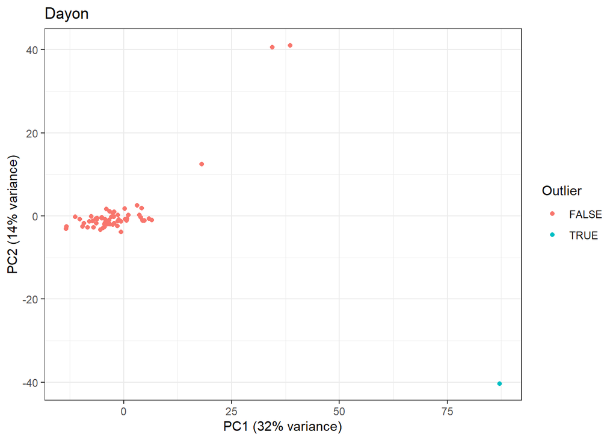

```
## [1] "The following were removed from: Dayon S116_AD"
```

#### T-test

```r
Dayon_ttest <- Ttest_AD(Dayonproteinclinical) %>%
  dplyr::mutate(FC = estimate1 - estimate2) %>%
  dplyr::select(ID, FC, p.adj)
```

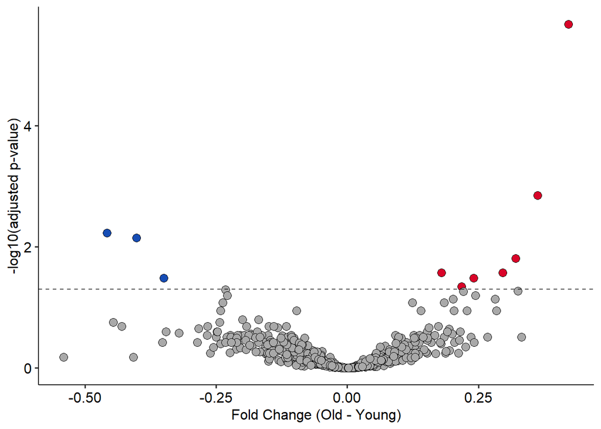

```r
# put CSV, XLS, and PDF in a collection
DT::datatable(Dayon_ttest, extensions = 'Buttons', options = list(dom = 'Bfrtip', buttons = list('copy', 'print', list(extend = 'collection',
        buttons = c('csv', 'excel'),text = 'Download' ))))
```

|  | ID | FC | p.adj |
| --- | --- | --- | --- |
| 1 | A6NGN9_IGLON5 | -0.0867125266271156 | 0.633143382352941 |
| 2 | A6NL88_SHISA7 | -0.0205478652967841 | 0.963133462282398 |
| 3 | A6NLU5_VSTM2B | 0.00335929616846542 | 0.997096518987342 |
| 4 | O00391_QSOX1 | -0.0965958374517975 | 0.114036 |
| 5 | O00451_GFRA2 | 0.00875367513907221 | 0.993410256410256 |
| 6 | O00461_GOLIM4 | -0.0172516084295751 | 0.939629629629629 |
| 7 | O00462_MANBA | -0.104942155511724 | 0.387492366412214 |
| 8 | O00468_AGRN | 0.0129770798155064 | 0.973868940754039 |
| 9 | O00533_CHL1 | 0.0365178579517611 | 0.92201052631579 |
| 10 | O00584_RNASET2 | -0.0487242284019125 | 0.783214285714286 |

[output cut: 635 more lines]

### Omar

#### Normalization

We normalize on reference samples. These have the substring Ref (or Rof.. Again, small writing mistake) We do work on un-log transformed data here.

```r
#First calculate per sample the median intensity.
#Then take the mean of all those medians.
Omar_protein_clean_references <-
  Omar_protein_clean %>%
  mutate(Intensity = 2^Intensity) %>%
  dplyr::filter(grepl('Ref|Rof', Sample)) %>%
  group_by(Sample) %>%
  summarise(PerSampleMedian = median(Intensity, na.rm = TRUE)) %>%
  ungroup() %>%
  summarise(AverageMedian = mean(PerSampleMedian))
Omar_averagemedianofreferences <- mean(Omar_protein_clean_references$AverageMedian)

#Only select samples, calculate median per sample.
#Determine per sample normalization factor
#apply it to intensity column.
#clean up.
Omar_protein_clean_noreferences <-
  Omar_protein_clean %>%
  mutate(Intensity = 2^Intensity)%>%
  dplyr::filter(!grepl('Bool|SP', Sample)) %>%
  group_by(Sample) %>%
  mutate(PerSampleMedian = median(Intensity, na.rm = TRUE)) %>%
  mutate(NormalizeFactor = Omar_averagemedianofreferences/ PerSampleMedian) %>%
  mutate(Intensity = Intensity * NormalizeFactor) %>%
  ungroup() %>%
  mutate(Intensity = log2(Intensity)) %>%
  select(ID, Sample, Intensity)
```

#### mean calculation

This dataset had duplicates. We take average of each. Made a small mistake by not applying underscore everywhere. Remove it to solve the issue.

```r
#split sample name
#group sample_a and ID
#Replace intensity by mean of the two.
#only take one of the two.
#remove NaN's, clean up columns
Omar_protein_clean_averaged <-
Omar_protein_clean_noreferences %>%
  mutate(Sample = str_remove_all(Sample, "_")) %>%
  mutate(sample_b = substr(Sample, 3, 3)) %>% #260160 rows
  mutate(Sample = str_to_title(substr(Sample, 1,2))) %>%
  group_by(Sample, ID) %>%
  mutate(Intensity = mean(Intensity, na.rm = TRUE)) %>%
  dplyr::filter(sample_b == "1") %>%
  na_if("NaN") %>%
  select(ID, Sample, Intensity)
```

#### Clinical

This dataset had AD, control and PSP. Only take AD and Control.

```r
Omarproteinclinical <- Omar_protein_clean_averaged %>%
  dplyr::filter(grepl('A|C', Sample)) %>%
  mutate(sample_b = substr(Sample, 1, 1)) %>%
  mutate(DX = ifelse(sample_b == "A", "AD", "C")) %>%
  select(ID, Sample, DX, Intensity)
```

#### Outlier Selection

```r
Omarproteinclinical_NO <- OutlierRemover(Omarproteinclinical, "Omar")
```

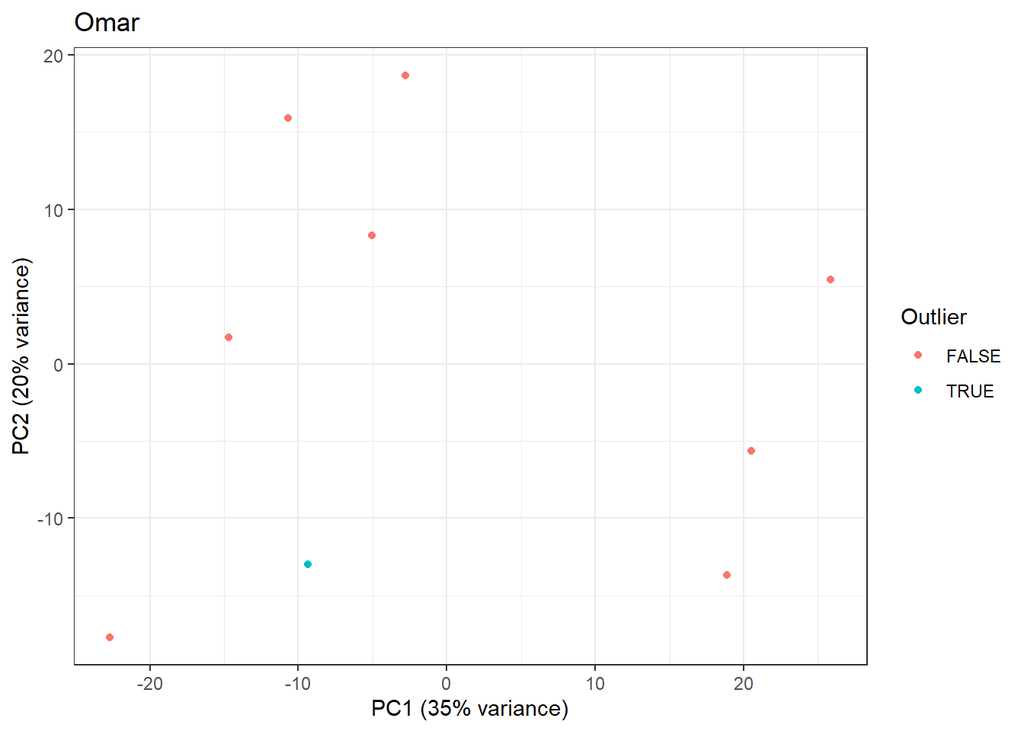

```
## [1] "The following were removed from: Omar C5_C"
```

#### T-test

```r
omar_ttest <- Ttest_AD(Omarproteinclinical_NO) %>%
  dplyr::mutate(FC = estimate1 - estimate2) %>%
  dplyr::select(ID, FC, p.adj)
```

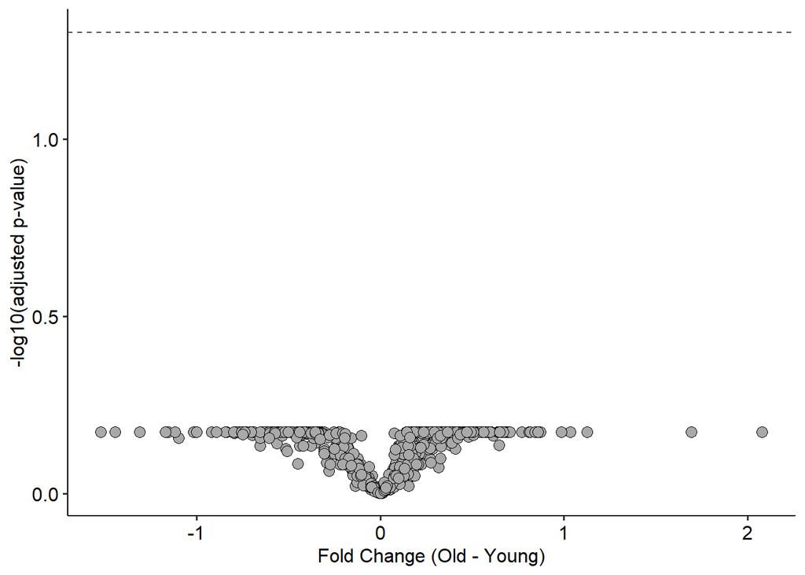

```r
# put CSV, XLS, and PDF in a collection
DT::datatable(omar_ttest, extensions = 'Buttons', options = list(dom = 'Bfrtip', buttons = list('copy', 'print', list(extend = 'collection',
        buttons = c('csv', 'excel'),text = 'Download' ))))
```

|  | ID | FC | p.adj |
| --- | --- | --- | --- |
| 1 | A0A075B6H7_IGKV3-7 | -0.441764131723158 | 0.697674329501916 |
| 2 | A0A075B6H9_IGLV4-69 | -0.279512861623804 | 0.861774147727273 |
| 3 | A0A075B6I0_IGLV8-61 | -0.793711090010746 | 0.674857819905213 |
| 4 | A0A075B6I9_IGLV7-46 | -0.476081078146937 | 0.670448924731183 |
| 5 | A0A075B6K4_IGLV3-10 | -0.916663575706828 | 0.670448924731183 |
| 6 | A0A075B6K5_IGLV3-9 | -0.352229833276883 | 0.718896810506567 |
| 7 | A0A075B6P5_IGKV2-28 | -0.769150346433275 | 0.670448924731183 |
| 8 | A0A075B6R2_IGHV4-4 | -0.515653663751777 | 0.745453448275862 |
| 9 | A0A075B6R9_IGKV2D-24 | -0.631840143183069 | 0.670448924731183 |
| 10 | A0A075B6S9_IGKV1-37 | -0.652928978591513 | 0.731303411131059 |

[output cut: 853 more lines]

### Sathe

#### Normalization

We determine the summed intensity (un-transformed) of each sample. We take the median value of all those summed intensities and use that for normalization.

```r
Sathe_medianSummedIntensity <- mean((
  Sathe_protein_clean %>%
  mutate_all(~replace(., . == 0, NA)) %>%
  group_by(Sample) %>%
  summarise(PerSampleSum = sum(Intensity, na.rm = TRUE)) %>%
  ungroup() %>%
  summarise(medianOfSummedIntensities = median(PerSampleSum)))$medianOfSummedIntensities)

Sathe_protein_normalized <-
Sathe_protein_clean %>%
  group_by(Sample) %>%
  mutate(PerSampleSum = sum(Intensity, na.rm = TRUE)) %>%
  mutate(NormalizeFactor = Sathe_medianSummedIntensity/ PerSampleSum) %>%
  mutate(Intensity = Intensity * NormalizeFactor) %>%
  ungroup() %>%
  select(ID, Sample, Intensity) %>%
  mutate_all(~replace(., . == 0, NA)) %>%
  mutate(Intensity = log2(Intensity))
```

#### Mean Calculation

This dataset had duplicates. We take average of each.

```r
#clean and split sample name
#Replace intensity by mean of the two.
#only take one of the two.
#remove NaN's, clean up columns
Sathe_protein_clean_averaged <-
  Sathe_protein_clean %>%
  separate(Sample, c("Sample", "second")) %>%
  group_by(Sample, ID) %>%
  mutate(Intensity = mean(Intensity, na.rm = TRUE)) %>%
  dplyr::filter(second == "1") %>%
  na_if("NaN") %>%
  select(ID, Sample, Intensity)
```

#### Clinical

clinical variables were described in manuscript. We extract it from TMT label.

```r
Satheproteinclinical <-
  Sathe_protein_clean_averaged %>%
  mutate(AD= grepl("C",Sample)) %>%
  mutate(DX = ifelse(AD == TRUE, "C", "AD")) %>%
  select(ID, Sample, DX, Intensity)
```

#### Outlier Selection

```r
Satheproteinclinical_NO <- OutlierRemover(Satheproteinclinical, "Sathe")
```

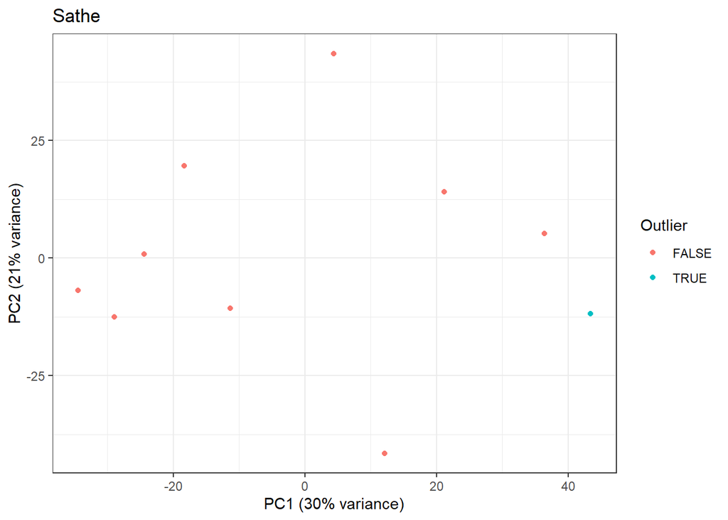

```
## [1] "The following were removed from: Sathe AD5_AD"
```

#### T-test

```r
sathe_ttest <- Ttest_AD(Satheproteinclinical_NO) %>%
  dplyr::mutate(FC = estimate1 - estimate2) %>%
  dplyr::select(ID, FC, p.adj)
```

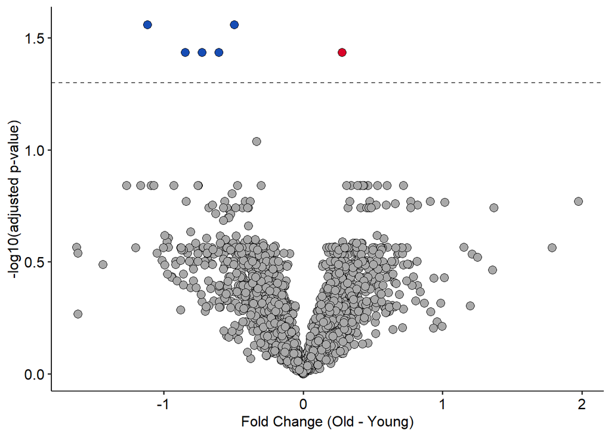

```r
# put CSV, XLS, and PDF in a collection
DT::datatable(sathe_ttest, extensions = 'Buttons', options = list(dom = 'Bfrtip', buttons = list('copy', 'print', list(extend = 'collection',
        buttons = c('csv', 'excel'),text = 'Download' ))))
```

|  | ID | FC | p.adj |
| --- | --- | --- | --- |
| 1 | A0A075B6I1_IGLV4-60 | 0.508770222481882 | 0.402825473321859 |
| 2 | A0A075B6S5_IGKV1-27 | -0.463958961557527 | 0.440293296089385 |
| 3 | A0A0B4J1V1_IGHV3-21 | 0.717049074986521 | 0.513740740740741 |
| 4 | A0A0B4J2D5_GATD3B | -0.10428123156203 | 0.788125 |
| 5 | A0A0U1RRL7_MMP24OS | -0.00210996911175698 | 0.997957006369427 |
| 6 | A0A1B0GVK7_FAM240A | -0.316364484099214 | 0.374463286004057 |
| 7 | A1L4H1_SSC5D | 0.163302318941735 | 0.406205657237937 |
| 8 | A2RU67_FAM234B | -0.0439262177332083 | 0.839406296851574 |
| 9 | A5A3E0_POTEF | 0.479037556723677 | 0.475433208489388 |
| 10 | A5D6W6_FITM1 | 1.35803418892787 | 0.344017494089835 |

[output cut: 2512 more lines]

### Lleo

#### Normalization

We determine the summed intensity (un-transformed) of each sample. We take the median value of all those summed intensities and use that for normalization

```r
Lleo_medianSummedIntensity <- mean(
  (Lleo_protein_clean %>%
  mutate_all(~replace(., . == 0, NA)) %>%
  group_by(Sample) %>%
  summarise(PerSampleSum = sum(Intensity, na.rm = TRUE)) %>%
  ungroup() %>%
  summarise(medianOfSummedIntensities = median(PerSampleSum)))$medianOfSummedIntensities
  )

Lleo_protein_normalized <-
Lleo_protein_clean %>%
  group_by(Sample) %>%
  mutate(PerSampleSum = sum(Intensity, na.rm = TRUE)) %>%
  mutate(NormalizeFactor = Lleo_medianSummedIntensity/ PerSampleSum) %>%
  mutate(Intensity = Intensity * NormalizeFactor) %>%
  ungroup() %>%
  select(ID, Sample, Intensity) %>%
  mutate_all(~replace(., . == 0, NA)) %>%
  mutate(Intensity = log2(Intensity))
```

#### Clinical

This dataset only has four samples. One is AD and 3 control. 01_01 –> AD1 02_02 –> C1 01_02 –> C4 02_01 –> C5 Each sample is the POOL of 10 samples.

```r
Lleoproteinclinical <- Lleo_protein_normalized %>%
  mutate(Sample = str_remove_all(Sample, " MaxLFQ Total Intensity")) %>%
  mutate(DX = ifelse(Sample == "01_01", "AD", "C")) %>%
  select(ID, Sample, DX, Intensity)
```

#### Outlier Selection

```r
Lleoproteinclinical_NO <- OutlierRemover(Lleoproteinclinical, "Lleo")
```

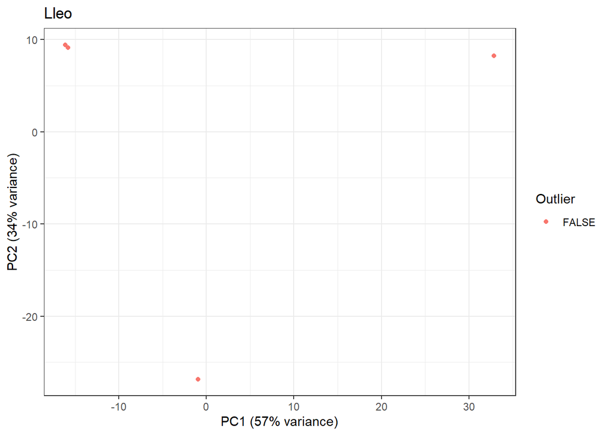

```
## [1] "The following were removed from: Lleo "
```

#### T-test

Not available in Lleo data due to single AD sample.

### Khoonsari

#### Normalization

We determine the summed intensity (un-transformed) of each sample. We take the median value of all those summed intensities and use that for normalization

```r
Khoonsari_medianSummedIntensity <- mean(
  (Khoonsari_protein_clean %>%
  mutate_all(~replace(., . == 0, NA)) %>%
  group_by(Sample) %>%
  summarise(PerSampleSum = sum(Intensity, na.rm = TRUE)) %>%
  ungroup() %>%
  summarise(medianOfSummedIntensities = median(PerSampleSum)))$medianOfSummedIntensities
  )

Khoonsari_protein_normalized <-
Khoonsari_protein_clean %>%
  group_by(Sample) %>%
  mutate(PerSampleSum = sum(Intensity, na.rm = TRUE)) %>%
  mutate(NormalizeFactor = Khoonsari_medianSummedIntensity/ PerSampleSum) %>%
  mutate(Intensity = Intensity * NormalizeFactor) %>%
  ungroup() %>%
  select(ID, Sample, Intensity) %>%
  mutate_all(~replace(., . == 0, NA)) %>%
  mutate(Intensity = log2(Intensity))
```

#### Mean Calculation

This dataset had duplicates. We take average of each.

```r
#clean and split sample name
#Replace intensity by mean of the two.
#only take one of the two.
#remove NaN's, clean up columns
Khoonsari_protein_clean_averaged <-
  Khoonsari_protein_normalized %>%
  mutate(Sample = str_remove_all(Sample, " Total Intensity")) %>%
  separate(Sample, c("Sample", "second")) %>%
  group_by(Sample, ID) %>%
  mutate(Intensity = mean(Intensity, na.rm = TRUE)) %>%
  dplyr::filter(second == "1") %>%
  na_if("NaN") %>%
  select(ID, Sample, Intensity)
```

#### Clinical

clinical data in rawfile name.

```r
Khoonsariproteinclinical <-
Khoonsari_protein_clean_averaged %>%
  mutate(AD= grepl("AD",Sample)) %>%
  mutate(DX = ifelse(AD == TRUE, "AD", "C")) %>%
  select(ID, Sample, DX, Intensity)
```

#### Outlier Selection

```r
Khoonsariproteinclinical_NO <- OutlierRemover(Khoonsariproteinclinical, "Khoonsari")
```

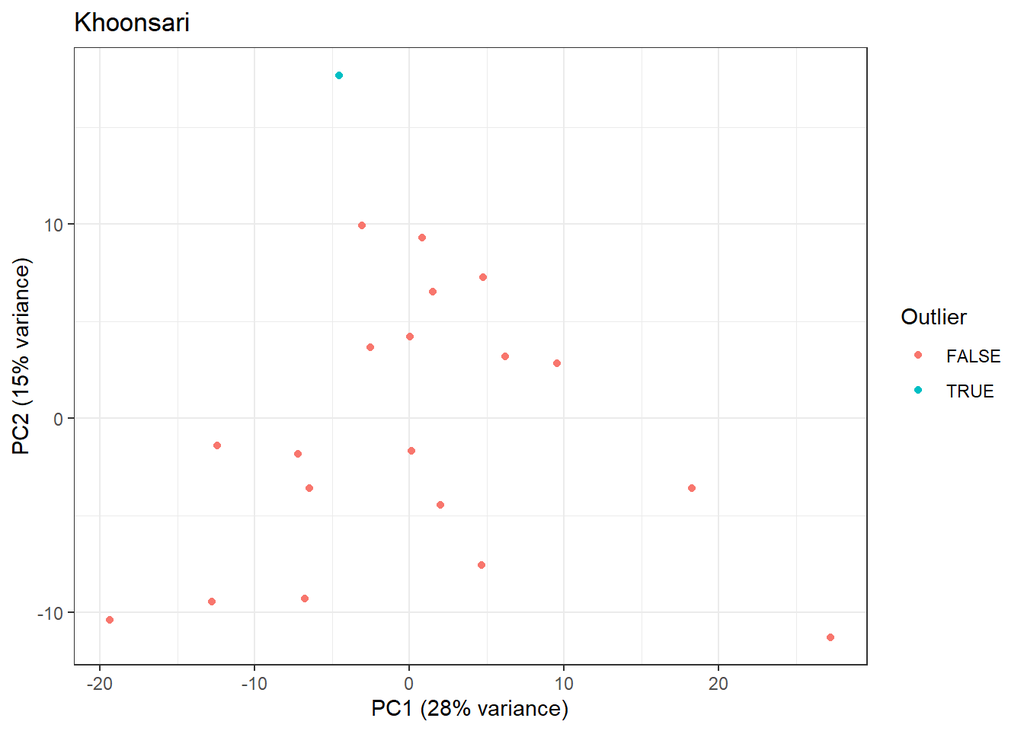

```
## [1] "The following were removed from: Khoonsari AD9_AD"
```

#### T-test

```r
khoonsari_ttest <- Ttest_AD(Khoonsariproteinclinical_NO) %>%
  dplyr::mutate(FC = estimate1 - estimate2) %>%
  dplyr::select(ID, FC, p.adj)
```

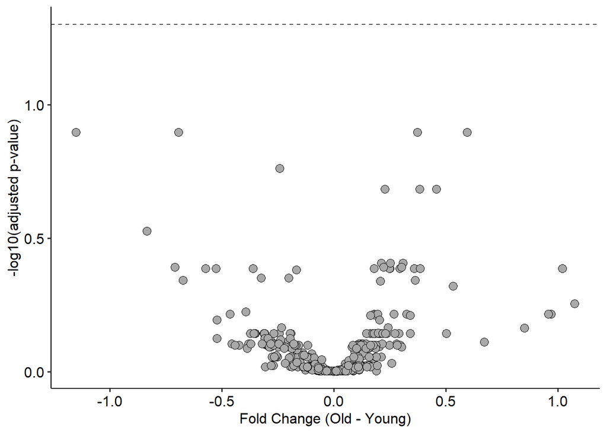

```r
# put CSV, XLS, and PDF in a collection
DT::datatable(khoonsari_ttest, extensions = 'Buttons', options = list(dom = 'Bfrtip', buttons = list('copy', 'print', list(extend = 'collection',
        buttons = c('csv', 'excel'),text = 'Download' ))))
```

|  | ID | FC | p.adj |
| --- | --- | --- | --- |
| 1 | A6NGN9_IGLON5 | 0.214116295645336 | 0.7208625 |
| 2 | A6NLU5_VSTM2B | 0.0467846122777793 | 0.986338414634147 |
| 3 | O00391_QSOX1 | -0.0714771145701008 | 0.986338414634147 |
| 4 | O00451_GFRA2 | -0.352065816909619 | 0.7208625 |
| 5 | O00468_AGRN | 0.0734441756465465 | 0.96013475177305 |
| 6 | O00533_CHL1 | -0.0520060382751915 | 0.986338414634147 |
| 7 | O00584_RNASET2 | -0.082324422279779 | 0.96013475177305 |
| 8 | O14498_ISLR | -0.241377522313197 | 0.173416 |
| 9 | O14594_NCAN | -0.107174813212708 | 0.950323529411765 |
| 10 | O14773_TPP1 | 0.0871931082843993 | 0.96013475177305 |

[output cut: 399 more lines]

### Multhaup

#### Normalization

We determine the summed intensity (un-transformed) of each sample. We take the median value of all those summed intensities and use that for normalization

```r
Multhaup_medianSummedIntensity <- mean(
  (Multhaup_protein_clean %>%
  mutate_all(~replace(., . == 0, NA)) %>%
  group_by(Sample) %>%
  summarise(PerSampleSum = sum(Intensity, na.rm = TRUE)) %>%
  ungroup() %>%
  summarise(medianOfSummedIntensities = median(PerSampleSum)))$medianOfSummedIntensities
  )

Multhaup_protein_normalized <-
Multhaup_protein_clean %>%
  group_by(Sample) %>%
  mutate(PerSampleSum = sum(Intensity, na.rm = TRUE)) %>%
  mutate(NormalizeFactor = Multhaup_medianSummedIntensity/ PerSampleSum) %>%
  mutate(Intensity = Intensity * NormalizeFactor) %>%
  ungroup() %>%
  select(ID, Sample, Intensity) %>%
  mutate_all(~replace(., . == 0, NA)) %>%
  mutate(Intensity = log2(Intensity))
```

#### Clinical

Clinical info is in the raw file name.

```r
Multhaupproteinclinical <-
Multhaup_protein_normalized %>%
  mutate(Sample = str_remove_all(Sample, " MaxLFQ Total Intensity")) %>%
  mutate(NAD= grepl("NAD",Sample)) %>%
  mutate(DX = ifelse(NAD == TRUE, "C", "AD")) %>%
  select(ID, Sample, DX, Intensity)
```

#### Outlier Selection

```r
Multhaupproteinclinical_NO <- OutlierRemover(Multhaupproteinclinical, "Multhaup")
```

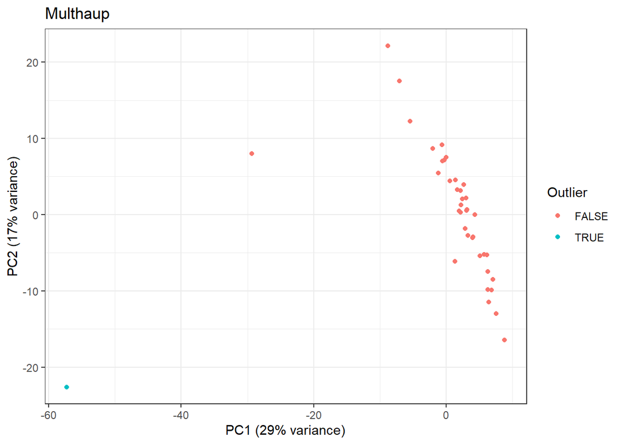

```
## [1] "The following were removed from: Multhaup AD_05_Probe_05_AD"
```

#### T-test

```r
multhaup_ttest <- Ttest_AD(Multhaupproteinclinical_NO) %>%
  dplyr::mutate(FC = estimate1 - estimate2) %>%
  dplyr::select(ID, FC, p.adj)
```

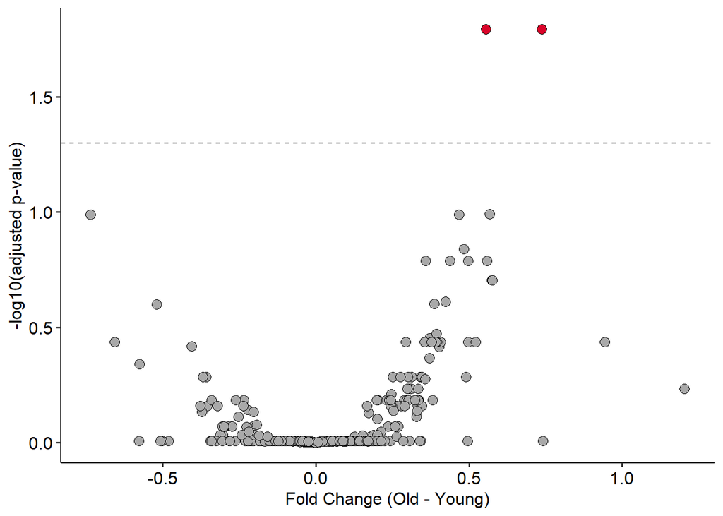

```r
# put CSV, XLS, and PDF in a collection
DT::datatable(multhaup_ttest, extensions = 'Buttons', options = list(dom = 'Bfrtip', buttons = list('copy', 'print', list(extend = 'collection',
        buttons = c('csv', 'excel'),text = 'Download' ))))
```

|  | ID | FC | p.adj |
| --- | --- | --- | --- |
| 1 | A6NGN9_IGLON5 | 0.0450375798723108 | 0.981524725274725 |
| 2 | A6NLU5_VSTM2B | -0.303408827253275 | 0.926390476190476 |
| 3 | O00391_QSOX1 | 0.147381725263806 | 0.981524725274725 |
| 4 | O00462_MANBA | -0.0558901518368451 | 0.981524725274725 |
| 5 | O00468_AGRN | -0.142752494631168 | 0.981524725274725 |
| 6 | O00533_CHL1 | -0.212134022379431 | 0.981524725274725 |
| 7 | O14498_ISLR | -0.0528731967726266 | 0.981524725274725 |
| 8 | O14594_NCAN | -0.152662243584448 | 0.981524725274725 |
| 9 | O14791_APOL1 | 0.105699359616221 | 0.981524725274725 |
| 10 | O14917_PCDH17 | 0.12207596829187 | 0.981524725274725 |

[output cut: 451 more lines]

### Wang

#### Normalization

We determine the summed intensity (un-transformed) of each sample. We take the median value of all those summed intensities and use that for normalization

```r
Wang_medianSummedIntensity <- mean(
  (Wang_protein_clean %>%
  mutate_all(~replace(., . == 0, NA)) %>%
  group_by(Sample) %>%
  summarise(PerSampleSum = sum(Intensity, na.rm = TRUE)) %>%
  ungroup() %>%
  summarise(medianOfSummedIntensities = median(PerSampleSum)))$medianOfSummedIntensities
  )

Wang_protein_normalized <-
Wang_protein_clean %>%
  group_by(Sample) %>%
  mutate(PerSampleSum = sum(Intensity, na.rm = TRUE)) %>%
  mutate(NormalizeFactor = Wang_medianSummedIntensity/ PerSampleSum) %>%
  mutate(Intensity = Intensity * NormalizeFactor) %>%
  ungroup() %>%
  select(ID, Sample, Intensity) %>%
  mutate_all(~replace(., . == 0, NA)) %>%
  mutate(Intensity = log2(Intensity))
```

#### Mean Calculation

This dataset had Triplicates We take average of each.

```r
#clean and split sample name
#Replace intensity by mean of the two.
#only take one of the two.
#remove NaN's, clean up columns
Wang_protein_clean_averaged <-
  Wang_protein_normalized %>%
  mutate(Sample = str_remove_all(Sample, " Total Intensity")) %>%
  separate(Sample, c("Sample", "second", "third", "fourth")) %>%
  mutate(Sample = paste(Sample, second,third, sep = "_")) %>%
  group_by(Sample, ID) %>%
  mutate(Intensity = mean(Intensity, na.rm = TRUE)) %>%
  dplyr::filter(fourth == "1") %>%
  na_if("NaN") %>%
  select(ID, Sample, Intensity)
```

#### Clinical

Clinical data given by group over email by Wang group.

```r
Wang_Clinical <- read_excel("Datasets/Wang_Clinical.xlsx")
Wang_Clinical$Sample <- as.character(Wang_Clinical$Sample)

#Split again for matching with excel table
Wang_protein_clean_averaged <- Wang_protein_clean_averaged %>%
   separate(Sample, c("first", "second", "third"), remove = F)

Wangproteinclinical <-
left_join(Wang_Clinical, Wang_protein_clean_averaged, by = c("Sample" = "third")) %>%
  mutate(Sample = Sample.y) %>%
  dplyr::filter(!DX == "MCI") %>%
  select(ID, Sample, DX, Intensity)
```

#### Outlier Selection

```r
Wangproteinclinical_NO <- OutlierRemover(Wangproteinclinical, "Wang")
```

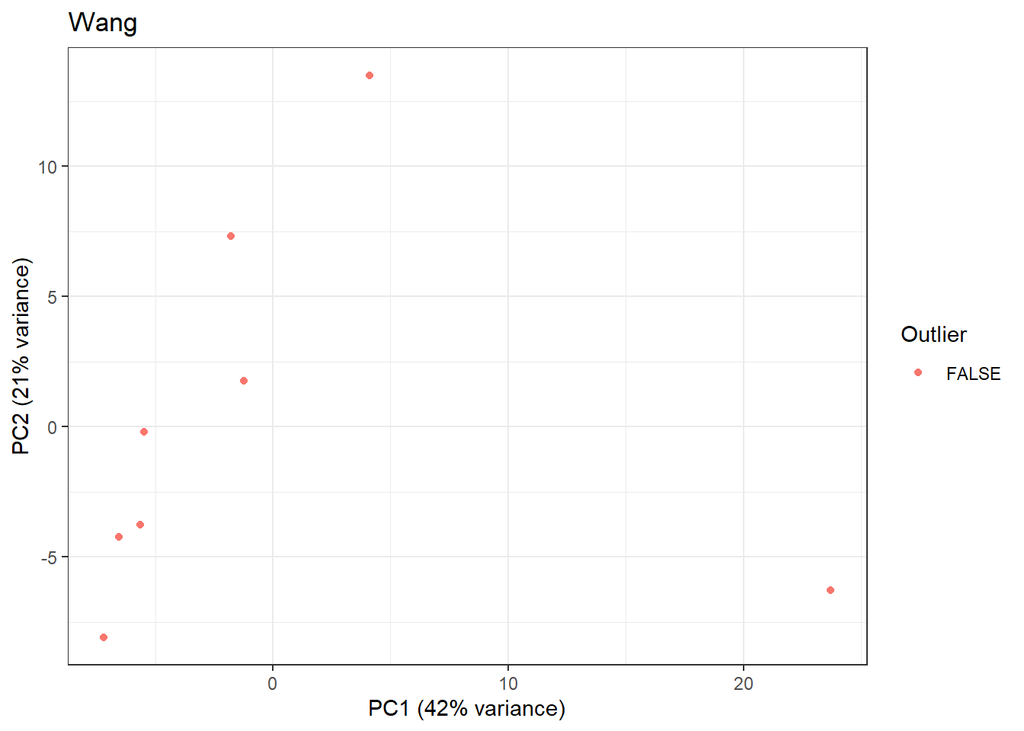

```
## [1] "The following were removed from: Wang "
```

#### T-test

```r
wang_ttest <- Ttest_AD(Wangproteinclinical_NO) %>%
  dplyr::mutate(FC = estimate1 - estimate2) %>%
  dplyr::select(ID, FC, p.adj)
```

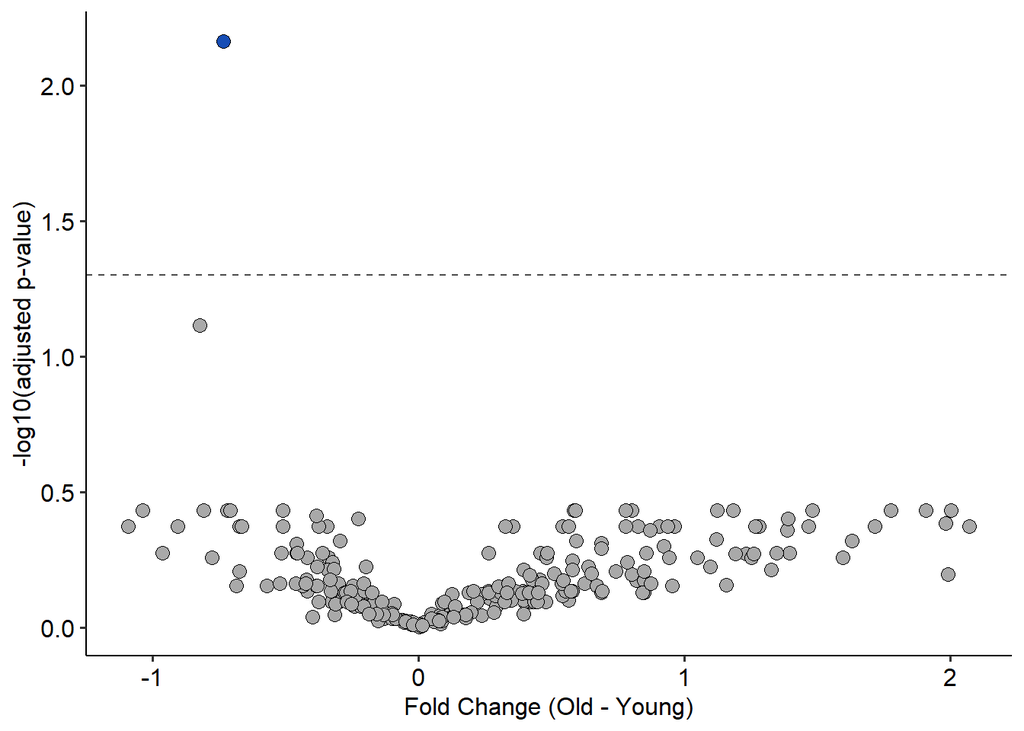

```r
# put CSV, XLS, and PDF in a collection
DT::datatable(wang_ttest, extensions = 'Buttons', options = list(dom = 'Bfrtip', buttons = list('copy', 'print', list(extend = 'collection',
        buttons = c('csv', 'excel'),text = 'Download' ))))
```

|  | ID | FC | p.adj |
| --- | --- | --- | --- |
| 1 | A0A075B6K5_IGLV3-9 | 1.09912755885534 | 0.595084337349398 |
| 2 | A0A075B6R2_IGHV4-4 | 0.741592424471104 | 0.620307692307692 |
| 3 | A0A075B7B8_IGHV3OR16-12 | 1.23333337954799 | 0.533647058823529 |
| 4 | A0A0B4J1V1_IGHV3-21 | 0.478953472731448 | 0.799826086956522 |
| 5 | A0A0B4J1X5_IGHV3-74 | 0.56647136592553 | 0.791127272727273 |
| 6 | A6NL88_SHISA7 | 0.326071581706678 | 0.759130434782609 |
| 7 | B9A064_IGLL5 | 0.392894032635557 | 0.730248175182482 |
| 8 | O00241_SIRPB1 | 0.422108196714788 | 0.799826086956522 |
| 9 | O00451_GFRA2 | 0.177868388595137 | 0.901833333333333 |
| 10 | O00533_CHL1 | -0.238732868311843 | 0.8316 |

[output cut: 242 more lines]

## Combining data & Z-scoring of Data

Add an identifier to each dataset, Z-score the data, combine the data (once for un-transformed, once for z-scored).

```r
Dayonproteinclinical_NO$Dataset <- "Dayon"
Omarproteinclinical_NO$Dataset <- "In-house"
Satheproteinclinical_NO$Dataset <- "Sathe"
Lleoproteinclinical_NO$Dataset <- "Lleó"
Khoonsariproteinclinical_NO$Dataset <- "Khoonsari"
Multhaupproteinclinical_NO$Dataset <- "Barucker"
Wangproteinclinical_NO$Dataset <- "Wang"

Allproteinclinical <- rbind(Dayonproteinclinical_NO,
                            Omarproteinclinical_NO,
                            Satheproteinclinical_NO,
                            Lleoproteinclinical_NO,
                            Khoonsariproteinclinical_NO,
                            Multhaupproteinclinical_NO,
                            Wangproteinclinical_NO)

#Function to Z-score Data
Z_Scorer <- function(dataset){

  MeanSD_DF <- dataset %>%
    group_by(ID) %>%
    filter(DX == "C") %>%
    summarise(mean = mean(Intensity, na.rm = T),
              sd = sd(Intensity, na.rm=T))

  Zscored <- left_join(dataset, MeanSD_DF, by = c("ID" = "ID")) %>%
    mutate(Z_score = (Intensity - mean)/sd) %>%
    dplyr::select(ID, Sample, DX, Z_score, Dataset)

  return(Zscored)
}

Dayonproteinclinical_Zscore <- Z_Scorer(Dayonproteinclinical_NO)
Omarproteinclinical_Zscore <- Z_Scorer(Omarproteinclinical_NO)
Satheproteinclinical_Zscore <- Z_Scorer(Satheproteinclinical_NO)
Lleoproteinclinical_Zscore <- Z_Scorer(Lleoproteinclinical_NO)
Khoonsariproteinclinical_Zscore <- Z_Scorer(Khoonsariproteinclinical_NO)
Multhaupproteinclinical_Zscore <- Z_Scorer(Multhaupproteinclinical_NO)
Wangproteinclinical_Zscore <- Z_Scorer(Wangproteinclinical_NO)

Allproteinclinical_Zscored <- rbind(Dayonproteinclinical_Zscore,
                            Omarproteinclinical_Zscore,
                            Satheproteinclinical_Zscore,
                            Lleoproteinclinical_Zscore,
                            Khoonsariproteinclinical_Zscore,
                            Multhaupproteinclinical_Zscore,
                            Wangproteinclinical_Zscore)
```

## PCA Plots before After Z-scoring

To see the effect of Z-scoring we make a PCA plot before and after.

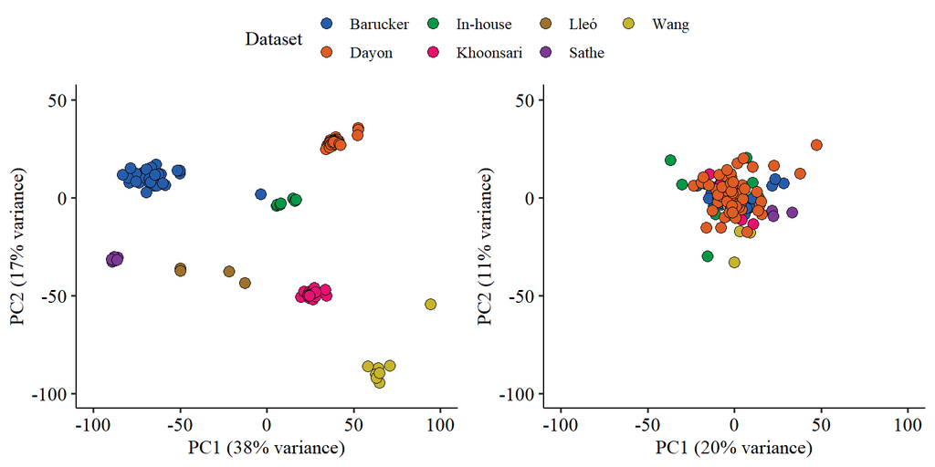

```r
PCA_PLOT <- function(dataset, dataset2) {

  #PCA PLOT: 70% cut off
  ProteinsToKeep <- dataset %>%
    group_by(ID) %>%
    summarise(PercentMissing = sum(!is.na(Intensity))/ length(unique(dataset$Sample))) %>%
    mutate(remove = PercentMissing > 0.7) %>%
    dplyr::filter(remove == T)

  #Half minimum value (per protein) imputation
  #We do a spread gather repeat to create rows because for some proteins there was not even a row hence we cant impute it.
  PCA_DF <-
  dataset %>%
    dplyr::filter(ID %in% ProteinsToKeep$ID) %>%
    group_by(ID) %>%
    spread(key = "ID", value = "Intensity") %>%
    gather(key = "ID", value = "Intensity", unique(ProteinsToKeep$ID)) %>%
    mutate(IntensImputed = replace_na(Intensity, mean(Intensity, na.rm = T)/2)) %>%
    mutate(SampleDX = paste0(Sample,"/", DX, "/", Dataset)) %>%
    select(ID, SampleDX, IntensImputed) %>%
    spread(key = "ID", value = "IntensImputed") %>%
    column_to_rownames("SampleDX")

  #scale and PCA
  PCA_DF_Results <- prcomp(as.matrix(PCA_DF))
  eigs <- PCA_DF_Results$sdev^2
  variance_percentage <- (eigs / sum(eigs))*100
  pc1var <- round(variance_percentage[1],digits=0)
  pc2var <- round(variance_percentage[2],digits=0)

  #Plot
  plot1 <- data.frame(PCA_DF_Results$x) %>%
    rownames_to_column() %>%
    separate(rowname, c("Sample", "DX", "Dataset"), "/") %>%
    ggplot(aes(x = PC1, y = PC2, fill = Dataset)) +
    geom_point(size = 3, shape = 21) +
    theme_pubr() +
    theme(text = element_text(family="serif")) +
    xlim(-100, 100) +
    ylim(-100, 50) +
    scale_fill_few("Dark") +
    xlab(paste('PC1',' (',pc1var,'% variance)',sep='')) +
    ylab(paste('PC2',' (',pc2var,'% variance)',sep=''))


  #Half minimum value (per protein) imputation
  #We do a spread gather repeat to create rows because for some proteins there was not even a row hence we cant impute it.
  PCA_DF <-
  dataset2 %>%
    dplyr::filter(ID %in% ProteinsToKeep$ID) %>%
    group_by(ID) %>%
    spread(key = "ID", value = "Z_score") %>%
    gather(key = "ID", value = "Z_score", unique(ProteinsToKeep$ID)) %>%
    mutate(IntensImputed = replace_na(Z_score, mean(Z_score, na.rm = T)/2)) %>%
    mutate(SampleDX = paste0(Sample,"/", DX, "/", Dataset)) %>%
    select(ID, SampleDX, IntensImputed) %>%
    spread(key = "ID", value = "IntensImputed") %>%
    column_to_rownames("SampleDX")

  #scale and PCA
  PCA_DF_Results <- prcomp(as.matrix(PCA_DF))
  eigs <- PCA_DF_Results$sdev^2
  variance_percentage <- (eigs / sum(eigs))*100
  pc1var <- round(variance_percentage[1],digits=0)
  pc2var <- round(variance_percentage[2],digits=0)

  #Plot
  plot2 <- data.frame(PCA_DF_Results$x) %>%
    rownames_to_column() %>%
    separate(rowname, c("Sample", "DX", "Dataset"), "/") %>%
    ggplot(aes(x = PC1, y = PC2, fill = Dataset)) +
    geom_point(size = 3, shape = 21) +
    theme_pubr() +
    theme(text = element_text(family="serif")) +
    xlim(-100, 100) +
    ylim(-100, 50) +
    scale_fill_few("Dark") +
    xlab(paste('PC1',' (',pc1var,'% variance)',sep='')) +
    ylab(paste('PC2',' (',pc2var,'% variance)',sep=''))

  plot(ggarrange(plot1, plot2, common.legend = T, legend = T))

}

PCA_PLOT_BeforeAfter <- PCA_PLOT(Allproteinclinical , Allproteinclinical_Zscored)
```

## T-test combined Dataset

Apply 70% cut off, run a T-test with Benjamini Hochberg Correction.

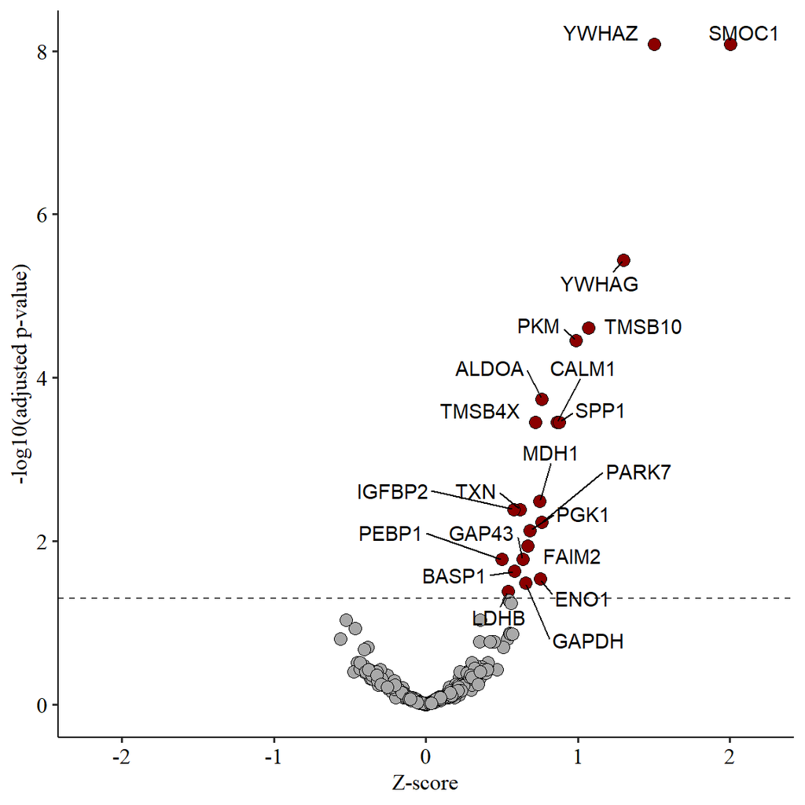

```r
Allproteinclinical_Zscored <- Allproteinclinical_Zscored %>%
   mutate(SampleDX = paste0(Sample,"/", DX, "/", Dataset))

ProteinsToKeep_all <- Allproteinclinical_Zscored %>%
    group_by(ID) %>%
    summarise(PercentMissing = sum(!is.na(Z_score))/ length(unique(Allproteinclinical_Zscored$SampleDX))) %>%
    mutate(remove = PercentMissing > 0.7) %>%
    dplyr::filter(remove == T)

Tttest_all <- Allproteinclinical_Zscored %>%
  dplyr::filter(ID %in% ProteinsToKeep_all$ID) %>%
    drop_na(Z_score) %>%
    drop_na(DX) %>%
    group_by(ID) %>%
    wilcox_test(Z_score ~ DX, detailed = T) %>%
    adjust_pvalue(method = "BH") %>%
  mutate(SIGNIFICANT = p.adj < 0.05) %>%
  mutate(log10_padj = -1*log10(p.adj))

Tttest_all <- Tttest_all %>%
  separate(ID, c("UniProt", "Gene"), remove = F)

VolcanoAll <- Tttest_all %>%
  ggplot(aes(x = estimate, y = log10_padj, fill = SIGNIFICANT)) +
  geom_point(size = 3, shape = 21) +
  geom_text_repel(aes(label = Gene), data = Tttest_all[Tttest_all$p.adj < 0.05,], box.padding = 0.5, max.overlaps = Inf) +
  scale_fill_manual(values = c("darkgrey", "darkred")) +
  theme_pubr() +
  geom_hline(yintercept = 1.3, linetype = 2, alpha = 0.7) +
    xlim(-2.2,2.2)+
    xlab("Z-score") +
    ylab("-log10(adjusted p-value)") +
  theme(legend.position= "none") +
  theme(text = element_text(family="serif"))

plot(VolcanoAll)
```

```r
Tttest_allDT <- Tttest_all %>%
  dplyr::mutate(FC = estimate) %>%
  dplyr::select(ID, FC, p.adj)


# put CSV, XLS, and PDF in a collection
DT::datatable(Tttest_allDT, extensions = 'Buttons', options = list(dom = 'Bfrtip', buttons = list('copy', 'print', list(extend = 'collection',
        buttons = c('csv', 'excel'),text = 'Download' ))))
```

|  | ID | FC | p.adj |
| --- | --- | --- | --- |
| 1 | A6NGN9_IGLON5 | -0.1452899779286 | 0.824454849498328 |
| 2 | A6NLU5_VSTM2B | -0.0539756793558762 | 0.92914364640884 |
| 3 | O00391_QSOX1 | -0.157800900258809 | 0.797475 |
| 4 | O00451_GFRA2 | -0.165723068185292 | 0.745435185185185 |
| 5 | O00461_GOLIM4 | 0.218902103445958 | 0.752135746606335 |
| 6 | O00462_MANBA | -0.34664611479828 | 0.439314285714286 |
| 7 | O00468_AGRN | 0.0743701239474892 | 0.878364179104478 |
| 8 | O00533_CHL1 | -0.0470661288644315 | 0.938222811671087 |
| 9 | O00584_RNASET2 | 0.18962996895718 | 0.816740157480315 |
| 10 | O14498_ISLR | -0.317463026170452 | 0.53501724137931 |

[output cut: 424 more lines]

## Heatmap Combined vs. Single.

Join all the dataframes for the siginificant proteins in the combined dataset to compare with the statistics of single datasets.

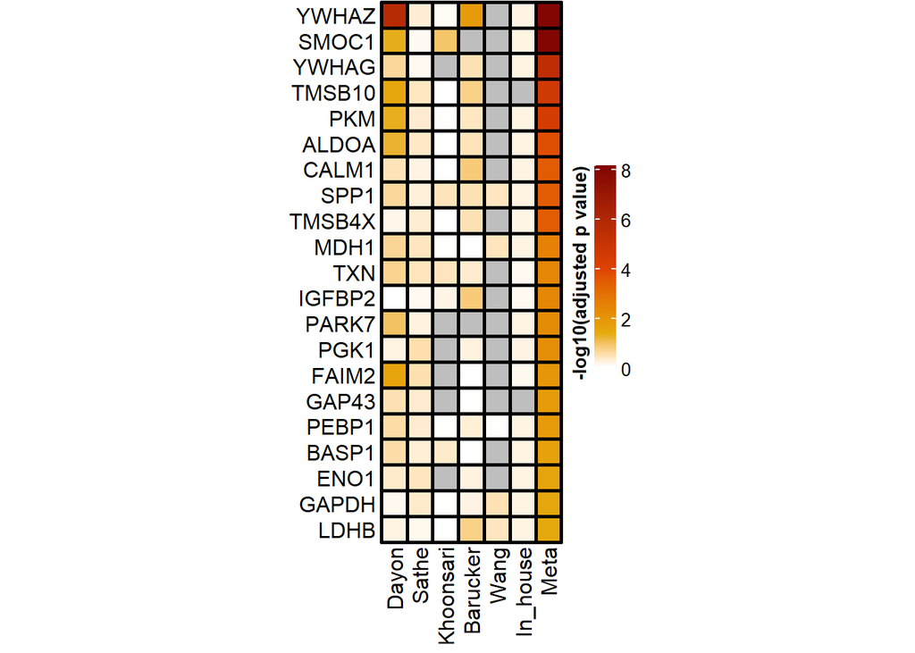

```r
SignificantHits <- Tttest_all %>%
  dplyr::filter(SIGNIFICANT == T)

HeatmapDF <- left_join(
    left_join(
      left_join(
        left_join(
          left_join(
            left_join(Dayon_ttest %>%
            filter(ID %in% SignificantHits$ID) %>%
            separate(ID, c("UniProt", "Gene"), remove = F) %>%
            mutate(Dayon = -1*log10(as.numeric(p.adj))) %>%
            select(Gene, Dayon),
            sathe_ttest %>%
            filter(ID %in% SignificantHits$ID) %>%
            separate(ID, c("UniProt", "Gene"), remove = F) %>%
            mutate(Sathe = -1*log10(as.numeric(p.adj))) %>%
            select(Gene, Sathe),
            by = c("Gene" = "Gene")),
            khoonsari_ttest %>%
            filter(ID %in% SignificantHits$ID) %>%
            separate(ID, c("UniProt", "Gene"), remove = F) %>%
            mutate(Khoonsari = -1*log10(as.numeric(p.adj))) %>%
            select(Gene, Khoonsari),
          by = c("Gene" = "Gene")),
            multhaup_ttest %>%
            filter(ID %in% SignificantHits$ID) %>%
            separate(ID, c("UniProt", "Gene"), remove = F) %>%
            mutate(Barucker = -1*log10(as.numeric(p.adj))) %>%
            select(Gene, Barucker),
          by = c("Gene" = "Gene")),
    wang_ttest %>%
    filter(ID %in% SignificantHits$ID) %>%
    separate(ID, c("UniProt", "Gene"), remove = F) %>%
    mutate(Wang = -1*log10(as.numeric(p.adj))) %>%
    select(Gene, Wang),
  by = c("Gene" = "Gene")),
    omar_ttest %>%
    filter(ID %in% SignificantHits$ID) %>%
    separate(ID, c("UniProt", "Gene"), remove = F) %>%
    mutate(In_house = -1*log10(as.numeric(p.adj))) %>%
    select(Gene, In_house),
  by = c("Gene" = "Gene")),
    Tttest_all %>%
    filter(ID %in% SignificantHits$ID) %>%
    separate(ID, c("UniProt", "Gene"), remove = F) %>%
    mutate(Meta = -1*log10(as.numeric(p.adj))) %>%
    select(Gene, Meta),
  by = c("Gene" = "Gene")) %>%
  arrange(Gene = desc(Meta)) %>%
  column_to_rownames("Gene")

col_fun = colorRamp2(c(0, 1.3, 4, 8), c("white","#E6AC0E", "#DE4203", "#840602"))
lgd = Legend(col_fun = col_fun, title = "-log10(adjusted p-value)")
Heatmap_ALL <- Heatmap(as.matrix(HeatmapDF),
        col = col_fun,
        cluster_rows = F,
        cluster_columns = F,
        row_names_side = c("left"),
        rect_gp = gpar(col = "black", lwd = 2.5),
        width = ncol(HeatmapDF)*unit(5, "mm"),
        height = nrow(HeatmapDF)*unit(5, "mm"),
        heatmap_legend_param = list(title = "-log10(adjusted p value)",
                                    legend_height = unit(4, "cm"),
                                    title_position = "lefttop-rot"))

plot(Heatmap_ALL)
```

## msgidb Hallmark Enrichment

Use the msgidb Hallmark enrichment dataset to see what proteins are affected in our combined dataset.

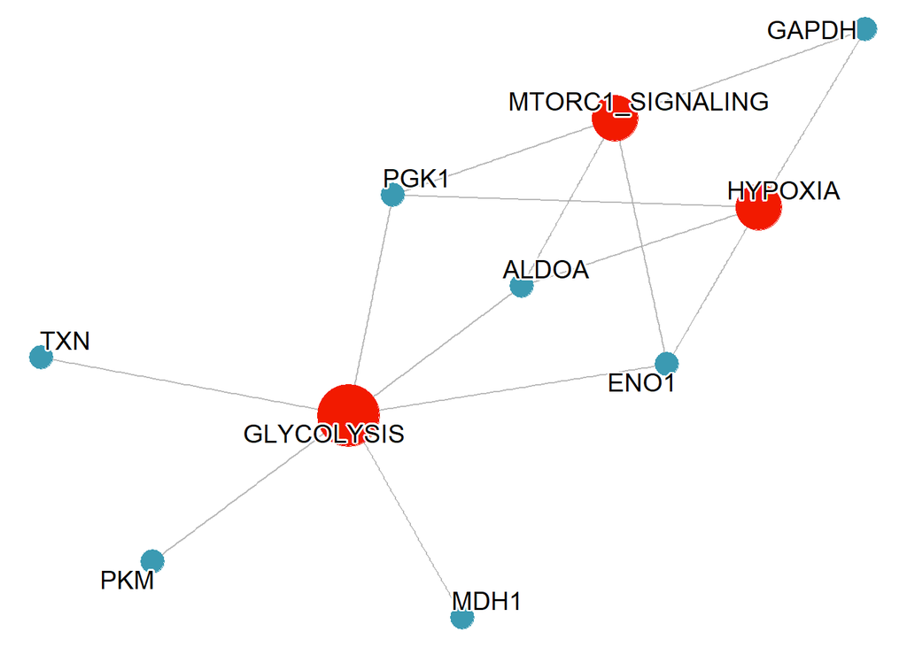

```r
SignificantHits <- Tttest_all %>%
  dplyr::filter(SIGNIFICANT == T)

all_gene_sets = msigdbr(species = "Homo sapiens", category = "H")
msigdbr_t2g = all_gene_sets %>%
  dplyr::distinct(gs_name, gene_symbol) %>%
  mutate(gs_name = str_remove_all(gs_name, "HALLMARK_")) %>% #REMOVE ALL THE HALLMARK STUFF
  as.data.frame()

enrichResults <- enricher(gene = SignificantHits$Gene, TERM2GENE = msigdbr_t2g)

#clusterProfiler::dotplot(enrichResults)

HallMarkPlot <- cnetplot(enrichResults, cex_category = 2, cex_label_category = 1, cex__label_gene = 1) +
  scale_color_manual(values = c("#3B9AB2", "#F21A00")) +
  theme(legend.position = "none") +
  theme(text = element_text(family="serif"))

plot(HallMarkPlot)
```

## KEGG Enrichment

Use the KEGG enrichment dataset to see what proteins are affected in our combined dataset.

```r
#Enrich for each colour
enrichtments <- enrichR::enrichr(SignificantHits$Gene,
                              c("KEGG_2021_Human"))
```

```
## Uploading data to Enrichr... Done.
##   Querying KEGG_2021_Human... Done.
## Parsing results... Done.
```

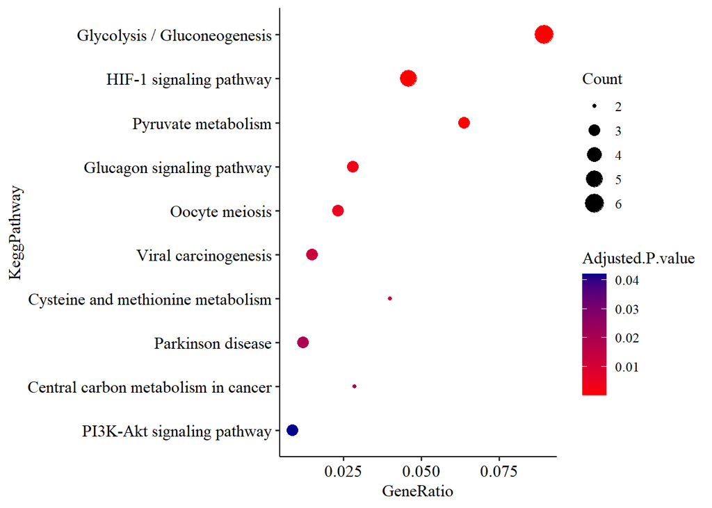

```r
myPalette <-colorRampPalette(rev(RColorBrewer::brewer.pal(11, "Spectral")))
sc <- scale_colour_gradientn(colours = myPalette(100), limits=c(0.0, 0.02))

KeggPlot <- enrichtments$KEGG_2021_Human %>%
  slice_head(n = 10) %>%
  mutate_at("Term", str_trunc, width = 45) %>%
  select(Term, Genes, Adjusted.P.value, Overlap) %>%
  mutate(KeggPathway = fct_reorder(Term, Adjusted.P.value, .desc = T)) %>%
  separate(Overlap, c("Count", "All")) %>%
  mutate(GeneRatio = as.numeric(Count)/ as.numeric(All)) %>%
  mutate(Count = as.numeric(Count)) %>%
  ggplot(aes(x = GeneRatio, y = KeggPathway, colour = Adjusted.P.value, )) +
  geom_point(aes(size=Count)) +
  scale_colour_gradient(low = "red", high = "darkblue") +
  theme_pubr() +
  theme(legend.position = "right") +
  theme(text = element_text(family="serif"))

plot(KeggPlot)
```

# 2. Pruning

This dataset (10 AD, 10 Control) was created in-house.

### Normalization

We determine the summed intensity (un-transformed) of each sample. We take the median value of all those summed intensities and use that for normalization.

```r
Zetterberg_medianSummedIntensity <- mean((
  Zetterberg_protein_clean %>%
  mutate_all(~replace(., . == 0, NA)) %>%
  group_by(Sample) %>%
  summarise(PerSampleSum = sum(Intensity, na.rm = TRUE)) %>%
  ungroup() %>%
  summarise(medianOfSummedIntensities = median(PerSampleSum)))$medianOfSummedIntensities)

Zetterberg_protein_normalized <-
Zetterberg_protein_clean %>%
  group_by(Sample) %>%
  mutate(PerSampleSum = sum(Intensity, na.rm = TRUE)) %>%
  mutate(NormalizeFactor = Zetterberg_medianSummedIntensity/ PerSampleSum) %>%
  mutate(Intensity = Intensity * NormalizeFactor) %>%
  ungroup() %>%
  select(ID, Sample, Intensity) %>%
  mutate_all(~replace(., . == 0, NA)) %>%
  mutate(Intensity = log2(Intensity))
```

### Outlier Selection

```r
#Add with Clinical
Zetterberg_protein_normalized <- Zetterberg_protein_normalized %>%
  separate(Sample, c("first", "second", "third", "fourth", "Sample")) %>%
  select(ID, Sample, Intensity)

Zetterberg_Clinical <- read_excel("Datasets/Zetterberg_Clinical.xlsx")

Zetterbergproteinclinical <- left_join(Zetterberg_Clinical, Zetterberg_protein_normalized, by = c("Sample" = "Sample")) %>%
  select(ID, Sample, DX, Intensity)

Zetterbergproteinclinical_NO <- OutlierRemover(Zetterbergproteinclinical, "Pruning Dataset")
```

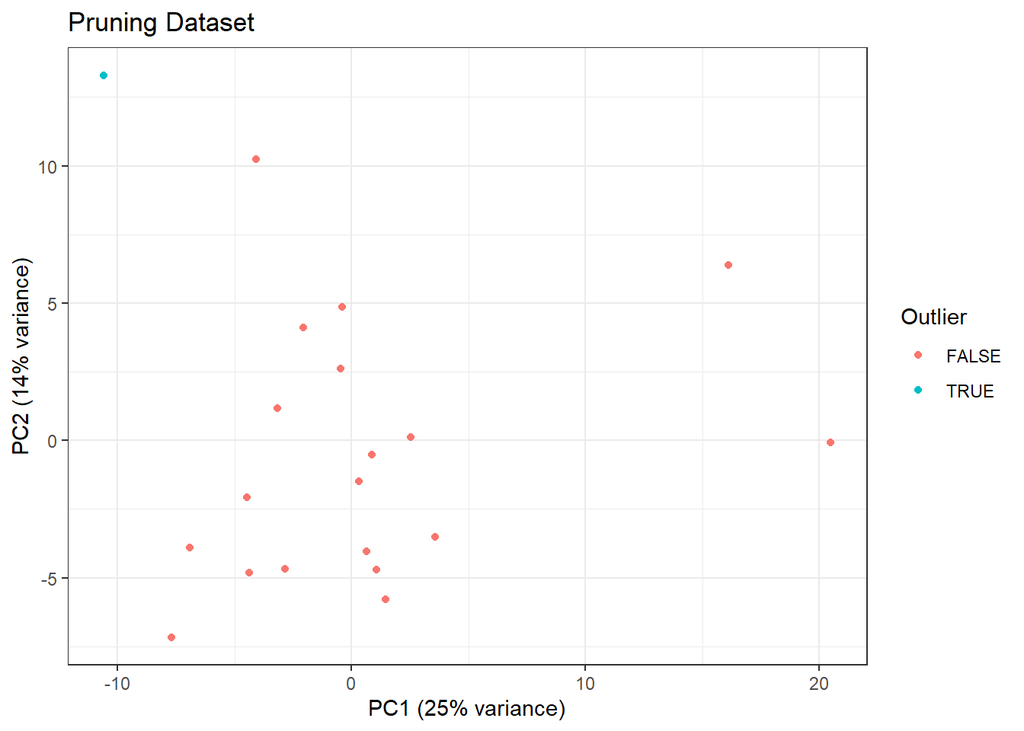

```
## [1] "The following were removed from: Pruning Dataset 2562_C"
```

### T-Test

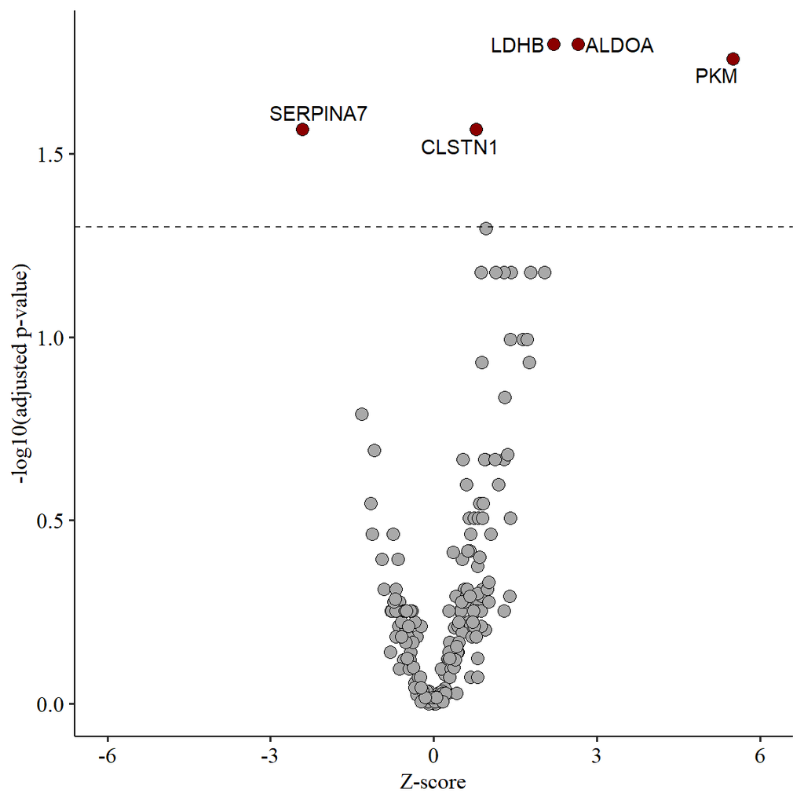

```r
Ttest_AD_Zscore <- function(dataset){
  #70% cut off
  ProteinsToKeep <- dataset %>%
    group_by(ID) %>%
    summarise(PercentMissing = sum(!is.na(Z_score))/ length(unique(dataset$Sample))) %>%
    mutate(remove = PercentMissing > 0.7) %>%
    dplyr::filter(remove == T)

  dataset_ttest <- dataset %>%
    filter(ID %in% ProteinsToKeep$ID) %>%
    drop_na(Z_score) %>%
    drop_na(DX) %>%
    group_by(ID) %>%
    wilcox_test(Z_score ~ DX, detailed = T) %>%
    adjust_pvalue(method = "BH") %>%
    mutate(SIGNIFICANT = p.adj < 0.05) %>%
  mutate(log10_padj = -1*log10(p.adj))

  return(dataset_ttest)
}
Zetterbergproteinclinical_NO$Dataset <- "Pruning"
Zetterbergproteinclinical_Zscore <- Z_Scorer(Zetterbergproteinclinical_NO)
Zetterberg_ttest <- Ttest_AD_Zscore(Zetterbergproteinclinical_Zscore)

Zetterberg_ttest <- Zetterberg_ttest %>%
  separate(ID, c("UniProt", "Gene"), remove = F)

VolcanoPruning <- Zetterberg_ttest %>%
  ggplot(aes(x = estimate, y = log10_padj, fill = SIGNIFICANT)) +
  geom_point(size = 3, shape = 21) +
  geom_text_repel(aes(label = Gene), data = Zetterberg_ttest[Zetterberg_ttest$p.adj < 0.05,], max.overlaps = Inf) +
  scale_fill_manual(values = c("darkgrey", "darkred")) +
  xlim(-6,6) +
  theme_pubr() +
  geom_hline(yintercept = 1.3, linetype = 2, alpha = 0.7) +
    #xlim(-2.6,2.6)+
    xlab("Z-score") +
    ylab("-log10(adjusted p-value)") +
  theme(legend.position= "none") +
  theme(text = element_text(family="serif"))

plot(VolcanoPruning)
```

```r
Zetterberg_ttestDT <- Zetterberg_ttest %>%
  dplyr::mutate(FC = estimate) %>%
  dplyr::select(ID, FC, p.adj)


# put CSV, XLS, and PDF in a collection
DT::datatable(Zetterberg_ttestDT, extensions = 'Buttons', options = list(dom = 'Bfrtip', buttons = list('copy', 'print', list(extend = 'collection',
        buttons = c('csv', 'excel'),text = 'Download' ))))
```

|  | ID | FC | p.adj |
| --- | --- | --- | --- |
| 1 | A0A075B6H7_IGKV3-7 | -0.638405010831718 | 0.615280373831776 |
| 2 | A0A075B6K5_IGLV3-9 | -0.351641752366718 | 0.876139072847682 |
| 3 | A0A0B4J1V0_IGHV3-15 | 0.679930595354886 | 0.845753333333333 |
| 4 | A0A0B4J1X5_IGHV3-74 | 0.299341987771576 | 0.845753333333333 |
| 5 | A0A0C4DH25_IGKV3D-20 | -1.32527306437439 | 0.161975 |
| 6 | A0A0J9YY99_NA | 0.146778625201878 | 0.936896551724138 |
| 7 | A0M8Q6_IGLC7 | -0.141403744696596 | 0.960126903553299 |
| 8 | B9A064_IGLL5 | -0.685151527966614 | 0.558098901098901 |
| 9 | O00533_CHL1 | 0.957041445251459 | 0.0505083333333333 |
| 10 | O00584_RNASET2 | 0.0163987269755109 | 1 |

[output cut: 199 more lines]

### Venny of All vs Pruning

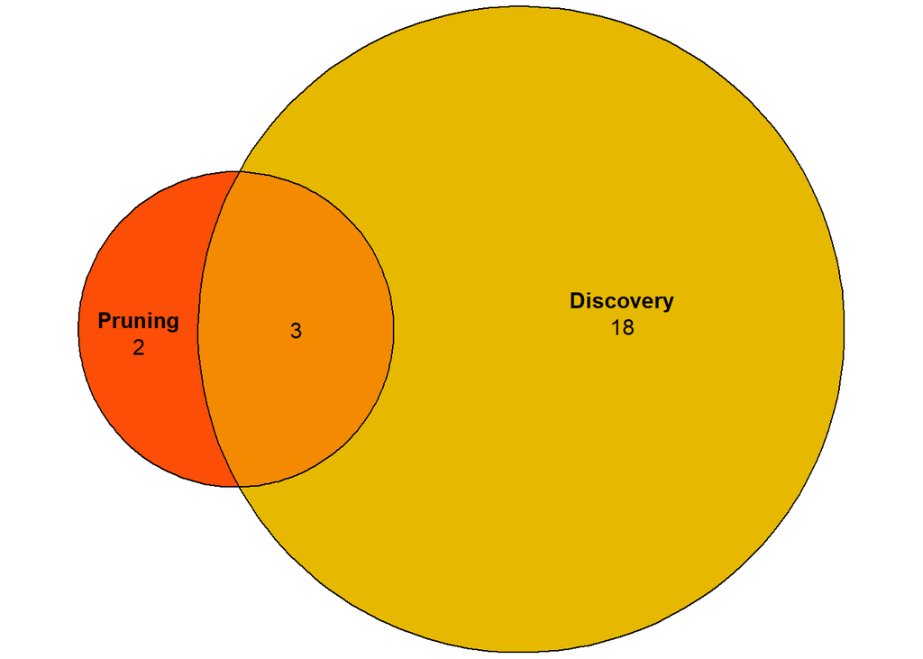

```r
PruningSignificant <- Zetterberg_ttest %>%
  filter(p.adj < 0.05)

VennyPruneMeta <- plot(euler(list(
      "Pruning" = PruningSignificant$Gene,
      "Discovery" = SignificantHits$Gene),
    shape = "ellipse"), quantities = T,
    fills = c("#FC4E07", "#E7B800")
)

plot(VennyPruneMeta)
```

### BoxPlots Pruning

We select the three overlapping Markers and visualize in boxplot.

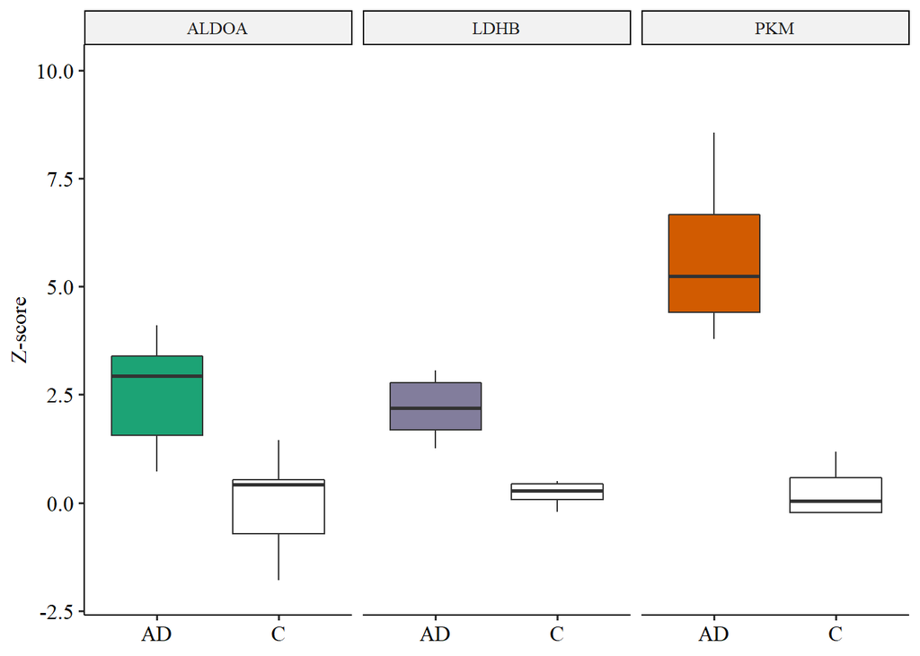

```r
Comparisons <- list(c("AD" , "C"))

Pruning_BoxPlot <-
  Zetterbergproteinclinical_Zscore %>%
  separate(ID, c("UniProt", "Gene"), remove = F) %>%
  filter(ID %in% c("P04075_ALDOA", "P14618_PKM", "P07195_LDHB")) %>%
  ggplot(aes(DX, Z_score)) +
  geom_boxplot(aes(fill = Gene, alpha = DX)) +
  facet_wrap(. ~ Gene) +
  scale_alpha_discrete(range = c(1, 0)) +
  scale_fill_manual(values = c("#1ca375", "#827d9c", "#d15b01")) +
  theme_pubr() +
  ylim(-2, 10)+
  ylab("Z-score") +
    theme(axis.title.x=element_blank(),
        legend.position = "none",
        text = element_text(family="serif"))
plot(Pruning_BoxPlot)
```

# 3. Validation

We will use two recent large-scale CSF proteomics datasets that are available. Those datasets were downloaded through the publications Supplementary data respositories. We import them here.

```r
Seyfried_DF <- read_excel("Datasets/Seyfried_resultmatrix.xlsx")
Seyfried_DF[Seyfried_DF == 0] <- NA
Mann_DF <- read_excel("Datasets/Mann_Matrix.xlsx")
Mann_DF[Mann_DF == 0] <- NA
```

## Johnson Data

Study used DDA TMT on a large cohort (Emory University, USA).

#### Prepare Johnson Data

Long format it, add AD vs. Control information based on sample names.

```r
##### SEYFRIED PREPARE
cl <- colnames(Seyfried_DF[2:ncol(Seyfried_DF)])

Seyfried_resultmatrix <-  Seyfried_DF %>%
  gather(cl, key = "Sample", value = "Intensity")

Seyfried_resultmatrix$DX <- grepl("Co", Seyfried_resultmatrix$Sample, fixed = T)
```

#### Boxplots of biomarker candidates

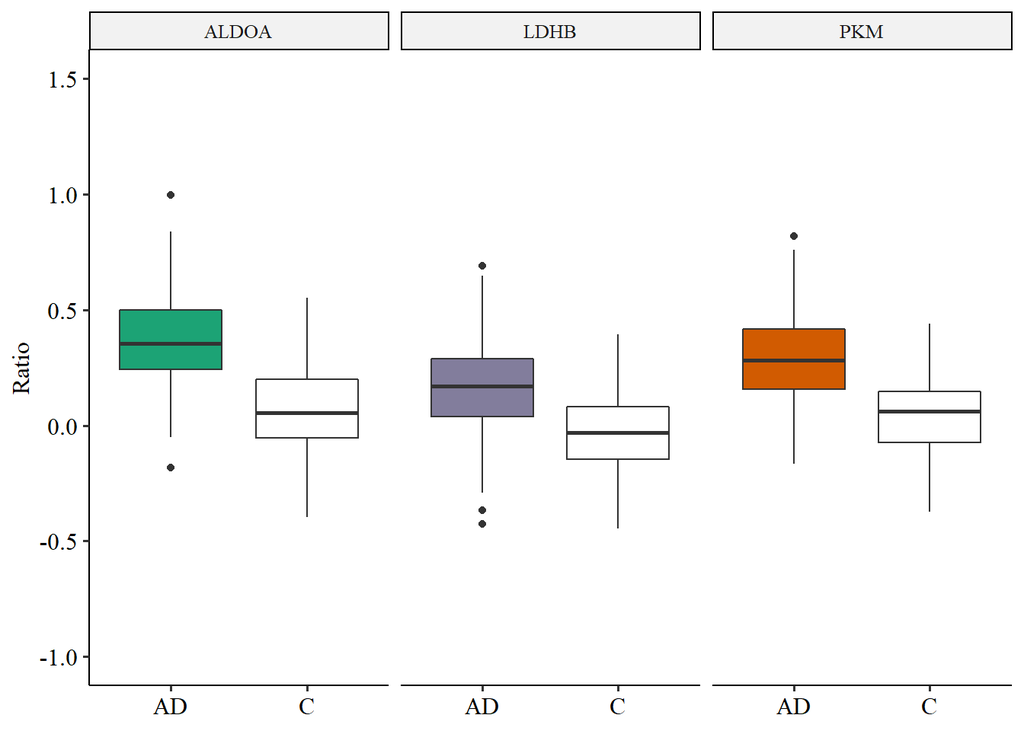

```r
Seyfried_BoxPlot <-
  Seyfried_resultmatrix %>%
    filter(rowID %in% c("P04075", "P14618", "P07195")) %>%
  mutate(Gene = ifelse(rowID == "P04075", "ALDOA", ifelse(rowID == "P14618", "PKM","LDHB"))) %>%
  mutate(DX = ifelse(DX == TRUE, "C","AD")) %>%
  ggplot(aes(DX, Intensity)) +
  geom_boxplot(aes(fill = Gene, alpha = DX)) +
  facet_wrap(. ~ Gene) +
  scale_alpha_discrete(range = c(1, 0)) +
  scale_fill_manual(values = c("#1ca375", "#827d9c", "#d15b01")) +
  theme_pubr() +
  ylim(-1, 1.5) +
  ylab("Ratio") +
    theme(axis.title.x=element_blank(),
        legend.position = "none",
        text = element_text(family="serif"))

plot(Seyfried_BoxPlot)
```

## Bader Data

Study used LFQ DIA on CSF samples from three cohorts.

#### Prepare Bader Data

Long format it, add AD vs. Control information based on sample names. This dataset contains a few (17) isoforms. We average them for downstream analysis.

```r
cl_mann <- colnames(Mann_DF[2:ncol(Mann_DF)])

Mann_resultmatrix <- Mann_DF %>%
  gather(cl_mann, key = "Sample", value = "Intensity") %>%
  mutate(Intensity = log2(Intensity))

Mann_resultmatrix$DX <- grepl("Co", Mann_resultmatrix$Sample, fixed = T)

#There is 17 proteins in this dataset where isoforms are specified.
#To make this data easily applicable to all the others, we average it.
Mann_resultmatrix <- Mann_resultmatrix %>%
  group_by(Sample, rowID, DX) %>%
  summarise(Intensity = mean(Intensity))
```

#### Boxplots of biomarker candidates

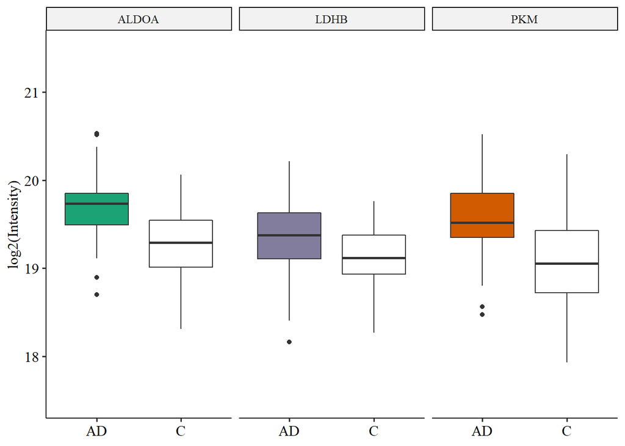

```r
Mann_BoxPlot <-
  Mann_resultmatrix %>%
  filter(rowID %in% c("P04075", "P14618", "P07195")) %>%
  mutate(Gene = ifelse(rowID == "P04075", "ALDOA", ifelse(rowID == "P14618", "PKM","LDHB"))) %>%
  mutate(DX = ifelse(DX == TRUE, "C","AD")) %>%
  ggplot(aes(DX, Intensity)) +
  geom_boxplot(aes(fill = Gene, alpha = DX)) +
  facet_wrap(. ~ Gene) +
  scale_alpha_discrete(range = c(1, 0)) +
  scale_fill_manual(values = c("#1ca375", "#827d9c", "#d15b01")) +
  theme_pubr() +
  ylim(17.5, 21.5) +
  ylab("log2(Intensity)") +
    theme(axis.title.x=element_blank(),
        legend.position = "none",
        text = element_text(family="serif"))

plot(Mann_BoxPlot)
```

## Biomarker Model Development

### Model Development

#### Develop Model Johnson

```r
Seyfried_ModelDF <- Seyfried_resultmatrix %>%
 dplyr::filter(rowID %in% c("P04075", "P14618", "P07195")) %>%
  select(Sample, 'rowID', DX, Intensity) %>%
  spread(key = "rowID", value = "Intensity")

Seyfried_ModelDF <- data.frame(Seyfried_ModelDF)
Seyfried_ModelDF$DX <- as.factor(Seyfried_ModelDF$DX)

#Create the Model
Seyfried_MarkerPanel <- glm(DX ~ P04075 + P14618 + P07195, data = Seyfried_ModelDF, family = 'binomial')
```

#### Develop Model Bader

```r
Mann_ModelDF <- Mann_resultmatrix %>%
 dplyr::filter(rowID %in% c("P04075", "P14618", "P07195")) %>%
  select(Sample, 'rowID', DX, Intensity) %>%
  spread(key = "rowID", value = "Intensity")

Mann_ModelDF$DX <- as.factor(Mann_ModelDF$DX)

#Create the Model
Mann_MarkerPanel <- glm(DX ~ P04075 + P14618 + P07195, data = Mann_ModelDF, family = 'binomial')
```

### Model Testing

#### Johnson Data

We observe a similair AUROC for the two models. We can thus assume that the three markers are effective at differentiating AD from Controls, indepedent from potential overfitting.

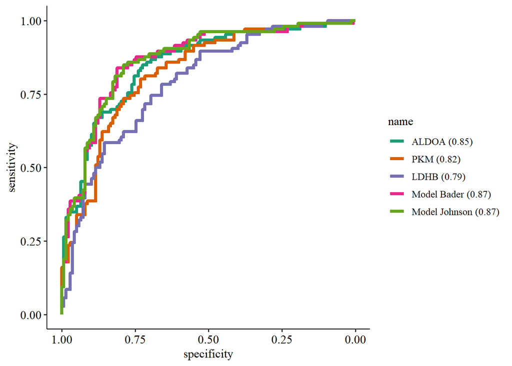

```r
Seyfried_ModelDF$Seyfried_panel <- predict(Seyfried_MarkerPanel, Seyfried_ModelDF)
Seyfried_ModelDF$Mann_panel <- predict(Mann_MarkerPanel, Seyfried_ModelDF)

Mann_ModelDF$Mann_panel <- predict(Mann_MarkerPanel, Mann_ModelDF)
Mann_ModelDF$Seyfried_panel <- predict(Seyfried_MarkerPanel, Mann_ModelDF)

seyfried_seyfriedmodel <- roc(DX ~ Seyfried_panel, Seyfried_ModelDF)
seyfried_mannmodel <- roc(DX ~ Mann_panel, Seyfried_ModelDF)
seyfried_ALDOA <- roc(DX ~ P04075, Seyfried_ModelDF)
seyfried_PKM <- roc(DX ~ P14618, Seyfried_ModelDF)
seyfried_LDHB <- roc(DX ~ P07195, Seyfried_ModelDF)

ROC_SEYFRIED <- ggroc(list("ALDOA (0.85)" = seyfried_ALDOA,
           "PKM (0.82)" = seyfried_PKM,
           "LDHB (0.79)" = seyfried_LDHB,
           "Model Bader (0.87)" = seyfried_mannmodel,
           "Model Johnson (0.87)" = seyfried_seyfriedmodel), lwd = 1.5) +
  scale_color_brewer(palette = "Dark2") +
  theme_pubr() +
  theme(legend.position = "right",
       text = element_text(family="serif")) +
  coord_fixed()

plot(ROC_SEYFRIED)
```

#### Bader Data

Again, we observe a similair AUROC for the two models. We can thus assume that the three markers are effective at differentiating AD from Controls, indepedent from potential overfitting.

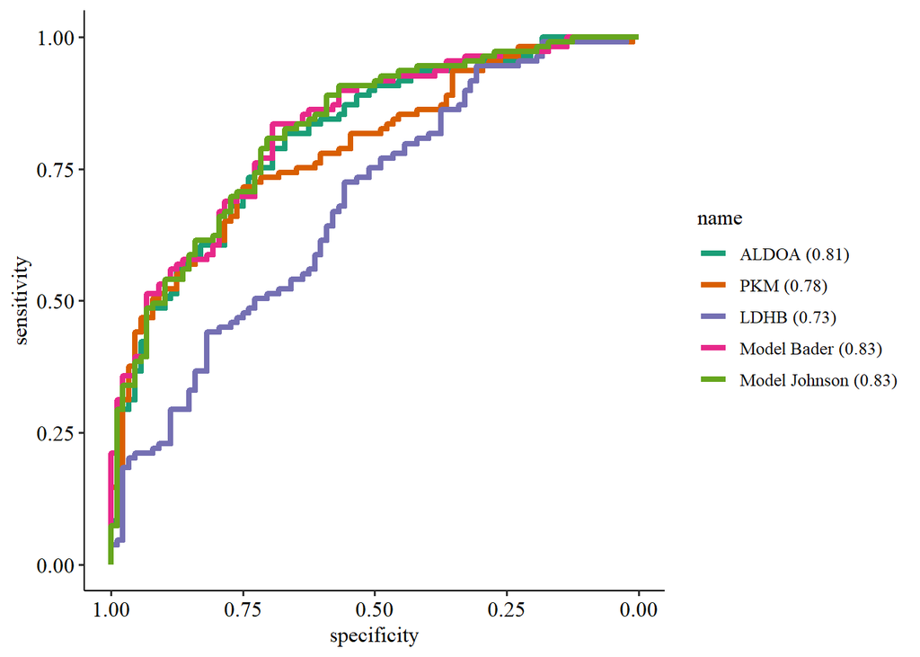

```r
Mann_seyfriedmodel <- roc(DX ~ Seyfried_panel, Mann_ModelDF)
Mann_mannmodel <- roc(DX ~ Mann_panel, Mann_ModelDF)
Mann_ALDOA <- roc(DX ~ P04075, Mann_ModelDF)
Mann_PKM <- roc(DX ~ P14618, Mann_ModelDF)
Mann_LDHB <- roc(DX ~ P07195, Mann_ModelDF)

ROC_MANN <- ggroc(list("ALDOA (0.81)" = Mann_ALDOA,
           "PKM (0.78)" = Mann_PKM,
           "LDHB (0.73)" = Mann_LDHB,
           "Model Bader (0.83)" = Mann_mannmodel,
           "Model Johnson (0.83)" = Mann_seyfriedmodel), lwd = 1.5) +
  scale_color_brewer(palette = "Dark2") +
  theme_pubr() +
  theme(legend.position = "right",
       text = element_text(family="serif"), aspect.ratio=1)

plot(ROC_MANN)
```